# Final Project: Insights on Traffic and Drug Violations

Na'Jae Batts

### Part 1: Introduction

#### 1. Context

The objective of my final project is to present data wrangling, inspecting the data, feature engineering, data analysis, data visualization, and story telling on traffic stop data. The dataset I chose is called [Traffic and Drug Related Violations Dataset](https://www.kaggle.com/datasets/shubamsumbria/traffic-violations-dataset/data) and I found it on Kaggle. This dataset has various information about traffic stops and violations along with information of the race, gender, and why the individuals were stopped.

#### 2. Structure of the Dataset

- **stop_date:** Date of violation
- **stop_time:** Time of violation
- **driver_gender:** Gender of violators(Male-M, Female-F)
- **driver_age:** Age of violators
- **driver_race:** Race of violators
- **violation:** Categories of violations: Speeding, Moving Violation (Reckless Driving, Hit and run, Assaulting another driver, pedestrian, improper turns and lane changes, etc),Equipment (Window tint violations, Headlight/taillights out, Loud exhaust, Cracked windshield, etc.), Registration/Plates,Seat Belt, or other (Call for Service, Violation of City/Town Ordinance, Suspicious Person, Motorist Assist/Courtesy, etc.)
- **search_conducted:** Whether search is conducted in True or False form
- **stop_outcome:** Result of violation
- **is_arrested:** Whether a person was arrested in True or False form
- **stop_duration:** Detained time for violators approx(in minutes)
- **drugs_related_stop:** Whether a person was involved in drug crime(True,False)

### Part 2: Data Wrangling

#### 1.Loading the Dataset

```python
import pandas as pd
import numpy as np
import matplotlib.pyplot as plt
import seaborn as sns
df = pd.read_csv('/Users/najaebatts/Desktop/Final DataScience/3_traffic_violaions (1).csv')
df
```

|  | stop_date | stop_time | country_name | driver_gender | driver_age_raw | driver_age | driver_race | violation_raw | violation | search_conducted | search_type | stop_outcome | is_arrested | stop_duration | drugs_related_stop |
| --- | --- | --- | --- | --- | --- | --- | --- | --- | --- | --- | --- | --- | --- | --- | --- |
| 0 | 1/2/2005 | 1:55 | NaN | M | 1985.0 | 20.0 | White | Speeding | Speeding | False | NaN | Citation | False | 0-15 Min | False |
| 1 | 1/18/2005 | 8:15 | NaN | M | 1965.0 | 40.0 | White | Speeding | Speeding | False | NaN | Citation | False | 0-15 Min | False |
| 2 | 1/23/2005 | 23:15 | NaN | M | 1972.0 | 33.0 | White | Speeding | Speeding | False | NaN | Citation | False | 0-15 Min | False |
| 3 | 2/20/2005 | 17:15 | NaN | M | 1986.0 | 19.0 | White | Call for Service | Other | False | NaN | Arrest Driver | True | 16-30 Min | False |
| 4 | 3/14/2005 | 10:00 | NaN | F | 1984.0 | 21.0 | White | Speeding | Speeding | False | NaN | Citation | False | 0-15 Min | False |
| ... | ... | ... | ... | ... | ... | ... | ... | ... | ... | ... | ... | ... | ... | ... | ... |
| 11287 | 10/26/2006 | 22:44 | NaN | F | 1986.0 | 20.0 | White | Speeding | Speeding | False | NaN | Citation | False | 0-15 Min | False |
| 11288 | 10/26/2006 | 22:45 | NaN | F | 1960.0 | 46.0 | White | Speeding | Speeding | False | NaN | Citation | False | 0-15 Min | False |
| 11289 | 10/27/2006 | 0:37 | NaN | M | 1984.0 | 22.0 | White | Other Traffic Violation | Moving violation | False | NaN | Citation | False | 0-15 Min | False |
| 11290 | 10/27/2006 | 0:53 | NaN | M | 1983.0 | 23.0 | White | Other Traffic Violation | Moving violation | False | NaN | Citation | False | 0-15 Min | False |
| 11291 | 10/27 | NaN | NaN | NaN | NaN | NaN | NaN | NaN | NaN | NaN | NaN | NaN | NaN | NaN | NaN |

11292 rows × 15 columns

Importing Libraries: In order to manipulate and visualize our data its important to import our libraries. Pandas provides us with our dataframes and series , Numpy provides supprot for arrays and math fucntions, matpolotlib is used for our visualizations as well as seaborn but seaborn is more advanced and imformative graphs.

The read_csv code loads the contents of my csv file onto my pandas datafram (df) and then prints it out so we can see the dataframe.

#### 2.Inspect the Data

```python
print(df.head(10))
```

```
   stop_date stop_time  country_name driver_gender  driver_age_raw  \
0   1/2/2005      1:55           NaN             M          1985.0
1  1/18/2005      8:15           NaN             M          1965.0
2  1/23/2005     23:15           NaN             M          1972.0
3  2/20/2005     17:15           NaN             M          1986.0
4  3/14/2005     10:00           NaN             F          1984.0
5  3/23/2005      9:45           NaN             M          1982.0
6   4/1/2005     17:30           NaN             M          1969.0
7   6/6/2005     13:20           NaN             F          1986.0
8  7/13/2005     10:15           NaN             M          1970.0
9  7/13/2005     15:45           NaN             M          1970.0

   driver_age driver_race                   violation_raw  violation  \
0        20.0       White                        Speeding   Speeding
1        40.0       White                        Speeding   Speeding
```

[output cut: 32 more lines]

Using the code:print(df.head(10)) it displays the first 10 rows of the Dataframe which is shown.

```python
# Print column names
print("Column Names:")
print(df.columns)
```

```
Column Names:
Index(['stop_date', 'stop_time', 'country_name', 'driver_gender',
       'driver_age_raw', 'driver_age', 'driver_race', 'violation_raw',
       'violation', 'search_conducted', 'search_type', 'stop_outcome',
       'is_arrested', 'stop_duration', 'drugs_related_stop'],
      dtype='object')
```

```python
# Print data types
print("\nData Types:")
print(df.dtypes)
```

```
Data Types:
stop_date              object
stop_time              object
country_name          float64
driver_gender          object
driver_age_raw        float64
driver_age            float64
driver_race            object
violation_raw          object
violation              object
search_conducted       object
search_type            object
stop_outcome           object
is_arrested            object
stop_duration          object
drugs_related_stop     object
dtype: object
```

To see the columns and datatypes of our dataframe, using the code print("Column names") or print("Data Types") will allow you to see that. It shows us all the column names we have which are the factors that are being measured in the dataset. The data types tells that our factors (which are our columns) are stored as an object or a float64. An object in our dataset means it contains string data which is regular text. A float64 in our dataset means we have floating point numbers which are decimal points, and 64 is the measure of memory so basically saying its a very small or very large number.

```python
# Count and Display the number of duplicate rows
duplicate_count = df.duplicated().sum()
print(f"Number of duplicate rows: {duplicate_count}")
```

```
Number of duplicate rows: 76
```

```python
# Display and print the duplicate rows
duplicates = df[df.duplicated()]
print("Duplicate Rows:")
print(duplicates)
```

```
Duplicate Rows:
        stop_date stop_time  country_name driver_gender  driver_age_raw  \
16      7/19/2005      0:30           NaN             M          1982.0
104     10/3/2005     13:26           NaN             M          1975.0
117     10/4/2005      0:36           NaN             M          1961.0
149     10/5/2005     10:00           NaN             M          1981.0
239     10/8/2005     12:30           NaN             M          1978.0
...           ...       ...           ...           ...             ...
10312   9/23/2006      2:20           NaN             M          1985.0
10372   9/25/2006      7:55           NaN           NaN             NaN
10473   9/29/2006      2:20           NaN             M          1972.0
10750   10/8/2006     22:13           NaN             M          1974.0
10914  10/14/2006      8:30           NaN             F          1981.0

       driver_age driver_race                   violation_raw  \
```

[output cut: 39 more lines]

To count and display the number of duplicate rows you can use the code above, which will check each row in the Dataframe.In the Dataframe it shows that in the dataset there is 76 duplicate rows in the dataseet. The amount of duplicate rows might not be good because it can indicate misrepresentation or data entry errors. When using the code to print duplicates, the output will show the coloumns in our dataset with all the duplicate rows.

```python
# Count the number of missing values in each column
missing_values_count = df.isnull().sum()
```

```python
# Display the count of missing values for each column
print("Missing Values Count:")
print(missing_values_count)
```

```
Missing Values Count:
stop_date                 0
stop_time                 1
country_name          11292
driver_gender           475
driver_age_raw          468
driver_age              520
driver_race             474
violation_raw           474
violation               474
search_conducted          1
search_type           10832
stop_outcome            474
is_arrested             474
stop_duration           474
drugs_related_stop        1
dtype: int64
```

#### 3. Data Cleaning

```python
# Copy the original DataFrame to a new DataFrame
df_new = df.copy()
df_new
```

|  | stop_date | stop_time | country_name | driver_gender | driver_age_raw | driver_age | driver_race | violation_raw | violation | search_conducted | search_type | stop_outcome | is_arrested | stop_duration | drugs_related_stop |
| --- | --- | --- | --- | --- | --- | --- | --- | --- | --- | --- | --- | --- | --- | --- | --- |
| 0 | 1/2/2005 | 1:55 | NaN | M | 1985.0 | 20.0 | White | Speeding | Speeding | False | NaN | Citation | False | 0-15 Min | False |
| 1 | 1/18/2005 | 8:15 | NaN | M | 1965.0 | 40.0 | White | Speeding | Speeding | False | NaN | Citation | False | 0-15 Min | False |
| 2 | 1/23/2005 | 23:15 | NaN | M | 1972.0 | 33.0 | White | Speeding | Speeding | False | NaN | Citation | False | 0-15 Min | False |
| 3 | 2/20/2005 | 17:15 | NaN | M | 1986.0 | 19.0 | White | Call for Service | Other | False | NaN | Arrest Driver | True | 16-30 Min | False |
| 4 | 3/14/2005 | 10:00 | NaN | F | 1984.0 | 21.0 | White | Speeding | Speeding | False | NaN | Citation | False | 0-15 Min | False |
| ... | ... | ... | ... | ... | ... | ... | ... | ... | ... | ... | ... | ... | ... | ... | ... |
| 11287 | 10/26/2006 | 22:44 | NaN | F | 1986.0 | 20.0 | White | Speeding | Speeding | False | NaN | Citation | False | 0-15 Min | False |
| 11288 | 10/26/2006 | 22:45 | NaN | F | 1960.0 | 46.0 | White | Speeding | Speeding | False | NaN | Citation | False | 0-15 Min | False |
| 11289 | 10/27/2006 | 0:37 | NaN | M | 1984.0 | 22.0 | White | Other Traffic Violation | Moving violation | False | NaN | Citation | False | 0-15 Min | False |
| 11290 | 10/27/2006 | 0:53 | NaN | M | 1983.0 | 23.0 | White | Other Traffic Violation | Moving violation | False | NaN | Citation | False | 0-15 Min | False |
| 11291 | 10/27 | NaN | NaN | NaN | NaN | NaN | NaN | NaN | NaN | NaN | NaN | NaN | NaN | NaN | NaN |

11292 rows × 15 columns

The orignal Dataframe that we were working on is being copied so that we can manipulate or change things in the Dataframe if needed without losing what we did with the first Dataframe.

```python
df = df.drop_duplicates()
df = df.drop_duplicates(keep=False)
print(df.copy)
```

```
<bound method NDFrame.copy of         stop_date stop_time  country_name driver_gender  driver_age_raw  \
0        1/2/2005      1:55           NaN             M          1985.0
1       1/18/2005      8:15           NaN             M          1965.0
2       1/23/2005     23:15           NaN             M          1972.0
3       2/20/2005     17:15           NaN             M          1986.0
4       3/14/2005     10:00           NaN             F          1984.0
...           ...       ...           ...           ...             ...
11287  10/26/2006     22:44           NaN             F          1986.0
11288  10/26/2006     22:45           NaN             F          1960.0
11289  10/27/2006      0:37           NaN             M          1984.0
11290  10/27/2006      0:53           NaN             M          1983.0
11291       10/27       NaN           NaN           NaN             NaN

       driver_age driver_race            violation_raw         violation  \
0            20.0       White                 Speeding          Speeding
```

[output cut: 38 more lines]

df = df.drop_duplicates() removes exact duplicate rows across our dataset. df = df.drop_duplicates(keep=False) also removes all duplicates. In this case, none of the duplicate rows will be kept; both the first and subsequent duplicates will be removed. Then I used the print code to print the copy csv, and at the bottom you can see there is now 11216 rows meaning 76 rows were removed which were all the duplicate rows.

```python
rows_with_3_or_more_empty = df_new.isnull().sum(axis=1) >= 3
df_cleaned = df_new[~rows_with_3_or_more_empty]
df_new = df_cleaned.drop(columns = ['country_name'])

df_new.isnull().sum()
```

```
stop_date                 0
stop_time                 0
driver_gender             0
driver_age_raw            0
driver_age                1
driver_race               0
violation_raw             0
violation                 0
search_conducted          0
search_type           10308
stop_outcome              0
is_arrested               0
stop_duration             0
drugs_related_stop        0
dtype: int64
```

For this code I dropped the rows that had 3 or more missing values. df_new.isnull() creates a boolean DataFrame where True represents a missing value (NaN). .sum(axis=1) counts the number of True values (i.e., missing values) in each row. 3 creates a boolean Series, where True means the row has 3 or more missing values. ~rows_with_3_or_more_empty inverts the boolean mask, selecting rows with fewer than 3 missing values. I then dropped the country name column because there were no values in the column at all therefore it was not needed for visualization. df_new.isnull().sum() shows the count of missing values in each column. All of the columns now have 0 except driver_age and search_type

```python
df_new.loc[df_new['search_type'].isna(), 'search_type'] = "Search not conducted"
```

```python
df_new.isnull().sum()
```

```
stop_date             0
stop_time             0
driver_gender         0
driver_age_raw        0
driver_age            1
driver_race           0
violation_raw         0
violation             0
search_conducted      0
search_type           0
stop_outcome          0
is_arrested           0
stop_duration         0
drugs_related_stop    0
dtype: int64
```

This code is used to fill the missing values in the 'search_type' column. The condition is df_new'search_type'.isna(), means its selecting the rows where the 'search_type' column is NaN. For the rows where 'search_type' is NaN, the value of 'search_type' is replaced with the string "Search not conducted". The reason why I did this is because most of the rows where there are missing values it means that the police didnt conduct a search.

```python
df_new.loc[:, "stop_datetime"] = pd.to_datetime(df_new["stop_date"] + " " + df_new["stop_time"])
df_new.loc[:, "stop_month"] = df_new["stop_datetime"].dt.month_name()
df_new.loc[:, "stop_year"] = df_new["stop_datetime"].dt.year
df_new.loc[:, "stop_hour"] = df_new["stop_datetime"].dt.hour
df_new.loc[:, "driver_age"] = df_new["stop_year"] - df_new["driver_age_raw"]
df_new
```

|  | stop_date | stop_time | driver_gender | driver_age_raw | driver_age | driver_race | violation_raw | violation | search_conducted | search_type | stop_outcome | is_arrested | stop_duration | drugs_related_stop | stop_datetime | stop_month | stop_year | stop_hour |
| --- | --- | --- | --- | --- | --- | --- | --- | --- | --- | --- | --- | --- | --- | --- | --- | --- | --- | --- |
| 0 | 1/2/2005 | 1:55 | M | 1985.0 | 20.0 | White | Speeding | Speeding | False | Search not conducted | Citation | False | 0-15 Min | False | 2005-01-02 01:55:00 | January | 2005 | 1 |
| 1 | 1/18/2005 | 8:15 | M | 1965.0 | 40.0 | White | Speeding | Speeding | False | Search not conducted | Citation | False | 0-15 Min | False | 2005-01-18 08:15:00 | January | 2005 | 8 |
| 2 | 1/23/2005 | 23:15 | M | 1972.0 | 33.0 | White | Speeding | Speeding | False | Search not conducted | Citation | False | 0-15 Min | False | 2005-01-23 23:15:00 | January | 2005 | 23 |
| 3 | 2/20/2005 | 17:15 | M | 1986.0 | 19.0 | White | Call for Service | Other | False | Search not conducted | Arrest Driver | True | 16-30 Min | False | 2005-02-20 17:15:00 | February | 2005 | 17 |
| 4 | 3/14/2005 | 10:00 | F | 1984.0 | 21.0 | White | Speeding | Speeding | False | Search not conducted | Citation | False | 0-15 Min | False | 2005-03-14 10:00:00 | March | 2005 | 10 |
| ... | ... | ... | ... | ... | ... | ... | ... | ... | ... | ... | ... | ... | ... | ... | ... | ... | ... | ... |
| 11286 | 10/26/2006 | 22:30 | M | 1930.0 | 76.0 | White | Speeding | Speeding | False | Search not conducted | Citation | False | 0-15 Min | False | 2006-10-26 22:30:00 | October | 2006 | 22 |
| 11287 | 10/26/2006 | 22:44 | F | 1986.0 | 20.0 | White | Speeding | Speeding | False | Search not conducted | Citation | False | 0-15 Min | False | 2006-10-26 22:44:00 | October | 2006 | 22 |
| 11288 | 10/26/2006 | 22:45 | F | 1960.0 | 46.0 | White | Speeding | Speeding | False | Search not conducted | Citation | False | 0-15 Min | False | 2006-10-26 22:45:00 | October | 2006 | 22 |
| 11289 | 10/27/2006 | 0:37 | M | 1984.0 | 22.0 | White | Other Traffic Violation | Moving violation | False | Search not conducted | Citation | False | 0-15 Min | False | 2006-10-27 00:37:00 | October | 2006 | 0 |
| 11290 | 10/27/2006 | 0:53 | M | 1983.0 | 23.0 | White | Other Traffic Violation | Moving violation | False | Search not conducted | Citation | False | 0-15 Min | False | 2006-10-27 00:53:00 | October | 2006 | 0 |

10768 rows × 18 columns

In order to handle my last column that had missing values which is driver_age I had to do a few things. I first had to combine stop_date and stop_time columns to create a new column called stop_datetime. This converts combined string into a datetime object using pd.to_datetime(). Then I added a new column, stop_month which extracts the exact month from the stop_datetime column. I also did the same thing by adding stop_year, along with extracting the hour from the same stop_datetime column to make a new column named stop_hour and this tells us the first number of the hour that the traffic stop happened. Since I converted the columns into a proper date time format I was then able to calculate the drivers age at the time of the stop. I did this by subtracting the drivers_age_raw column from stop_year. This is subtracting the year that the driver was born from the year which they got stopped, which will give us the drivers age of when they got stopped. Doing this will fill the missing value I had in my data for driver_age.

```python
df_new.isnull().sum()
```

```
stop_date             0
stop_time             0
driver_gender         0
driver_age_raw        0
driver_age            0
driver_race           0
violation_raw         0
violation             0
search_conducted      0
search_type           0
stop_outcome          0
is_arrested           0
stop_duration         0
drugs_related_stop    0
stop_datetime         0
stop_month            0
stop_year             0
stop_hour             0
dtype: int64
```

After using df_new.isnull().sum() to check for any missing values in my columns, you can see that there aren't any.

```python
set(df_new["driver_age_raw"].tolist())
```

```
{0.0,
 1918.0,
 1923.0,
 1924.0,
 1925.0,
 1926.0,
 1927.0,
 1928.0,
 1929.0,
 1930.0,
 1931.0,
 1932.0,
 1933.0,
 1934.0,
 1935.0,
 1936.0,
 1937.0,
 1938.0,
 1939.0,
 1940.0,
 1941.0,
 1942.0,
 1943.0,
 1944.0,
 1945.0,
 1946.0,
 1947.0,
 1948.0,
 1949.0,
 1950.0,
 1951.0,
 1952.0,
 1953.0,
 1954.0,
 1955.0,
 1956.0,
 1957.0,
 1958.0,
 1959.0,
 1960.0,
```

[output cut: 16 more lines]

```
 1977.0,
 1978.0,
 1979.0,
 1980.0,
 1981.0,
 1982.0,
 1983.0,
 1984.0,
 1985.0,
 1986.0,
 1987.0,
 1988.0,
 1989.0,
 1990.0,
 1991.0}
```

```python
df_new.loc[df_new['driver_age_raw'] == 0.0]
```

|  | stop_date | stop_time | driver_gender | driver_age_raw | driver_age | driver_race | violation_raw | violation | search_conducted | search_type | stop_outcome | is_arrested | stop_duration | drugs_related_stop | stop_datetime | stop_month | stop_year | stop_hour |
| --- | --- | --- | --- | --- | --- | --- | --- | --- | --- | --- | --- | --- | --- | --- | --- | --- | --- | --- |
| 5194 | 3/29/2006 | 14:00 | M | 0.0 | 2006.0 | Black | Speeding | Speeding | True | Protective Frisk | Warning | False | 16-30 Min | False | 2006-03-29 14:00:00 | March | 2006 | 14 |

Now I want to check for outliers. The code set(df_new"driver_age_raw".tolist()) is used to extract all the unique values from the driver_age_raw column in the df_new DataFrame and return them as a set. The tolist is a method is used to convert the pandas Series (the column df_new"driver_age_raw") into a regular Python list. This makes it easier to manipulate and allows it to be passed to functions like set(). As you can see the first data is '0.0' there isn't no way for someone to be born in that year. This value doesn't make sense to our dataset so it is an outlier. df_new.loc df_new'driver_age_raw' == 0.0 filters the dataframe and return all rows where the value of the driver_age_raw column is exactly 0.0. You can see that not only is the driver_age_raw is an outlier but so is the driver_age. It says 2006.0 and nobody is this age.

```python
set(df_new["driver_age"].tolist())
```

```
{15.0,
 16.0,
 17.0,
 18.0,
 19.0,
 20.0,
 21.0,
 22.0,
 23.0,
 24.0,
 25.0,
 26.0,
 27.0,
 28.0,
 29.0,
 30.0,
 31.0,
 32.0,
 33.0,
 34.0,
 35.0,
 36.0,
 37.0,
 38.0,
 39.0,
 40.0,
 41.0,
 42.0,
 43.0,
 44.0,
 45.0,
 46.0,
 47.0,
 48.0,
 49.0,
 50.0,
 51.0,
 52.0,
 53.0,
 54.0,
```

[output cut: 15 more lines]

```
 70.0,
 71.0,
 72.0,
 73.0,
 74.0,
 75.0,
 76.0,
 77.0,
 78.0,
 79.0,
 80.0,
 81.0,
 82.0,
 88.0,
 2006.0}
```

```python
df_new.loc[df_new['driver_age'] == 2006.0]
```

|  | stop_date | stop_time | driver_gender | driver_age_raw | driver_age | driver_race | violation_raw | violation | search_conducted | search_type | stop_outcome | is_arrested | stop_duration | drugs_related_stop | stop_datetime | stop_month | stop_year | stop_hour |
| --- | --- | --- | --- | --- | --- | --- | --- | --- | --- | --- | --- | --- | --- | --- | --- | --- | --- | --- |
| 5194 | 3/29/2006 | 14:00 | M | 0.0 | 2006.0 | Black | Speeding | Speeding | True | Protective Frisk | Warning | False | 16-30 Min | False | 2006-03-29 14:00:00 | March | 2006 | 14 |

After running the same code, you can see that in the driver_age there is the same outlier that we saw before of 2006. The 0.0 driver_age_raw and 2006.0 driver_age are under in the same row together.

```python
df_new.drop(df_new.iloc[5194].name, inplace=True)
```

```python
set(df_new["driver_age"].tolist())
```

```
{15.0,
 16.0,
 17.0,
 18.0,
 19.0,
 20.0,
 21.0,
 22.0,
 23.0,
 24.0,
 25.0,
 26.0,
 27.0,
 28.0,
 29.0,
 30.0,
 31.0,
 32.0,
 33.0,
 34.0,
 35.0,
 36.0,
 37.0,
 38.0,
 39.0,
 40.0,
 41.0,
 42.0,
 43.0,
 44.0,
 45.0,
 46.0,
 47.0,
 48.0,
 49.0,
 50.0,
 51.0,
 52.0,
 53.0,
 54.0,
```

[output cut: 15 more lines]

```
 70.0,
 71.0,
 72.0,
 73.0,
 74.0,
 75.0,
 76.0,
 77.0,
 78.0,
 79.0,
 80.0,
 81.0,
 82.0,
 88.0,
 2006.0}
```

```python
set(df_new["driver_age_raw"].tolist())
```

```
{0.0,
 1918.0,
 1923.0,
 1924.0,
 1925.0,
 1926.0,
 1927.0,
 1928.0,
 1929.0,
 1930.0,
 1931.0,
 1932.0,
 1933.0,
 1934.0,
 1935.0,
 1936.0,
 1937.0,
 1938.0,
 1939.0,
 1940.0,
 1941.0,
 1942.0,
 1943.0,
 1944.0,
 1945.0,
 1946.0,
 1947.0,
 1948.0,
 1949.0,
 1950.0,
 1951.0,
 1952.0,
 1953.0,
 1954.0,
 1955.0,
 1956.0,
 1957.0,
 1958.0,
 1959.0,
 1960.0,
```

[output cut: 16 more lines]

```
 1977.0,
 1978.0,
 1979.0,
 1980.0,
 1981.0,
 1982.0,
 1983.0,
 1984.0,
 1985.0,
 1986.0,
 1987.0,
 1988.0,
 1989.0,
 1990.0,
 1991.0}
```

### Part 3: Exploratory Data Analysis (EDA)

```python
df_new[['driver_age_raw', 'driver_age']].describe()
```

|  | driver_age_raw | driver_age |
| --- | --- | --- |
| count | 10767.000000 | 10767.000000 |
| mean | 1972.648277 | 33.120554 |
| std | 22.668411 | 22.668576 |
| min | 0.000000 | 15.000000 |
| 25% | 1965.000000 | 23.000000 |
| 50% | 1976.000000 | 30.000000 |
| 75% | 1983.000000 | 41.000000 |
| max | 1991.000000 | 2006.000000 |

```python
print(df_new['driver_gender'].value_counts())
print(df_new['driver_race'].value_counts())
print(df_new['violation'].value_counts())
print(df_new['stop_outcome'].value_counts())
```

```
driver_gender
M    7872
F    2895
Name: count, dtype: int64
driver_race
White       8923
Black       1284
Asian        312
Hispanic     217
Other         31
Name: count, dtype: int64
violation
Speeding               8125
Moving violation       1455
Equipment               675
Registration/plates     311
Other                   201
Name: count, dtype: int64
stop_outcome
Citation            9857
Arrest Driver        519
Warning              169
N/D                  132
Arrest Passenger      45
No Action             45
Name: count, dtype: int64
```

```python
print(df_new['driver_gender'].value_counts(normalize=True) * 100)
print(df_new['driver_race'].value_counts(normalize=True) * 100)
print(df_new['violation'].value_counts(normalize=True) * 100)
print(df_new['stop_outcome'].value_counts(normalize=True) * 100)
```

```
driver_gender
M    73.112288
F    26.887712
Name: proportion, dtype: float64
driver_race
White       82.873595
Black       11.925327
Asian        2.897743
Hispanic     2.015417
Other        0.287917
Name: proportion, dtype: float64
violation
Speeding               75.462060
Moving violation       13.513514
Equipment               6.269156
Registration/plates     2.888455
Other                   1.866815
Name: proportion, dtype: float64
stop_outcome
Citation            91.548249
Arrest Driver        4.820284
Warning              1.569611
N/D                  1.225968
Arrest Passenger     0.417944
No Action            0.417944
Name: proportion, dtype: float64
```

Right here you can see the same distribution of these categorical variables but instead in percentages for a deeper dive of analysis.

```python
# Filter the rows where drugs_related_stop is True (i.e., drug-related stops)
drug_related_stops = df_new[df_new['drugs_related_stop'] == True]
violation_counts = drug_related_stops['violation'].value_counts()
print(violation_counts)
```

```
violation
Speeding               25
Moving violation       18
Equipment              16
Registration/plates     3
Other                   2
Name: count, dtype: int64
```

```python
violation_percentage = drug_related_stops['violation'].value_counts(normalize=True) * 100
print(violation_percentage)
```

```
violation
Speeding               39.0625
Moving violation       28.1250
Equipment              25.0000
Registration/plates     4.6875
Other                   3.1250
Name: proportion, dtype: float64
```

In order to analyze the frequency and nature of violations under drugs_related_stop I used the codes above. It displays the violation and the different violations under which includes speeding, moving violation, equipment, registration/plates, and other violations. And then I also showed the percentages of each violation that was listed.

### Part 4: Data Visualization

#### 1. Demographic Distribution of Drivers

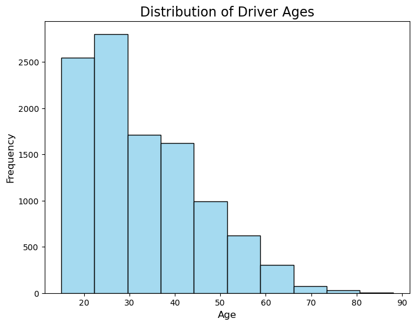

```python
# Create a histogram plot for driver_age
plt.figure(figsize=(8, 6))
sns.histplot(df['driver_age'], bins=10, kde=False, color='skyblue', edgecolor='black')

# Add title and labels
plt.title('Distribution of Driver Ages', fontsize=16)
plt.xlabel('Age', fontsize=12)
plt.ylabel('Frequency', fontsize=12)

# Show the plot
plt.show()
```

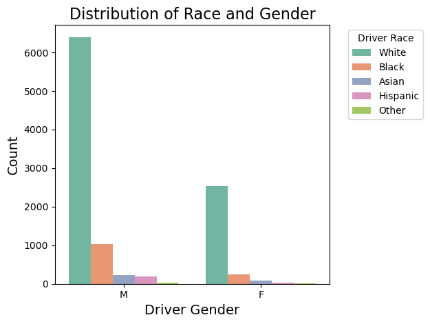

```python
#Use a countplot to visualize the distribution of driver_gender and driver_race
sns.countplot(x='driver_gender', hue='driver_race', data=df_new, palette='Set2')
plt.title('Distribution of Race and Gender', fontsize=16)
plt.xlabel('Driver Gender', fontsize=14)
plt.ylabel('Count', fontsize=14)
plt.xticks(rotation=0)
plt.legend(title='Driver Race', bbox_to_anchor=(1.05, 1), loc='upper left')
plt.tight_layout()
plt.show()
```

The code above displays countplots for both driver_gender and driver_race. The hue argument is now explicitly set to driver_race which is why it shows the hue to thr right.For the colors for the countplot I just used a palette so that each race had a different color. Then for every visualization I set the title, x axis, and y axis,set the legend, and then displayed the countplot.

#### 2. Violation Types

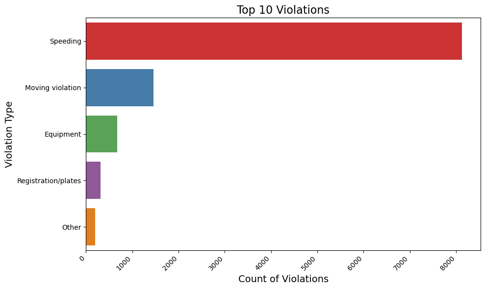

```python
# Get the top 10 most frequent violations
top_violations = df_new['violation'].value_counts().head(10)
plt.figure(figsize=(10, 6))
sns.barplot(x=top_violations.values, y=top_violations.index, hue=top_violations.index,palette='Set1')
plt.title('Top 10 Violations', fontsize=16)
plt.xlabel('Count of Violations', fontsize=14)
plt.ylabel('Violation Type', fontsize=14)
plt.xticks(rotation=45, ha='right')
plt.tight_layout()
plt.show()
```

Above I used the code to display a bar plot for the top 10 violations in the violaiton column. This required me to use df_new['violation'].value_counts().head(10) so we could already set it at the first 10. Then the palette 1 to use different colors for this visualization. Then I set the title, x axis and y axis labels.

What are the most common violations?: The most common violations are speeding and moving violations, followed by equipment, registration/plates, and other. Are there any patterns in the types of violations?: There aren't really no patterns regarding the violations because speeding makes up the most of the violations.

#### 3. Search and Arrest Outcome

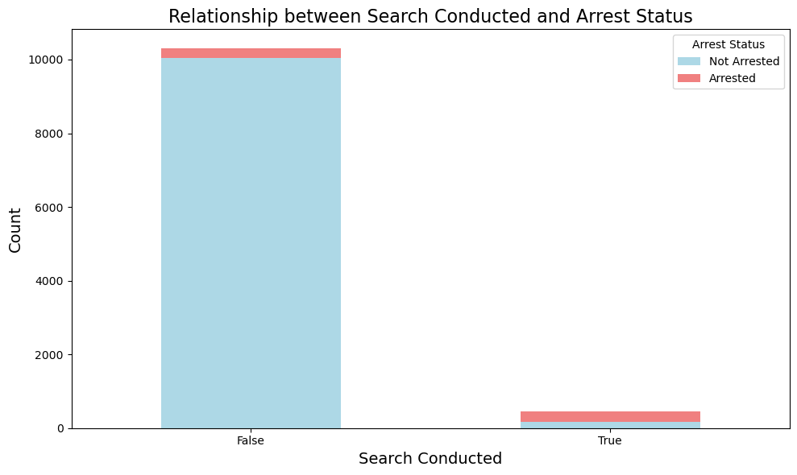

```python
#Use a stacked bar plot to show the relationship between search_conducted and is_arrested
#Create a crosstab to aggregate the counts between 'search_conducted'
crosstab = pd.crosstab(df_new['search_conducted'], df_new['is_arrested'], dropna=False)
crosstab.plot(kind='bar', stacked=True, figsize=(10, 6), color=['lightblue', 'lightcoral'])
plt.title('Relationship between Search Conducted and Arrest Status', fontsize=16)
plt.xlabel('Search Conducted', fontsize=14)
plt.ylabel('Count', fontsize=14)
plt.xticks(rotation=0)
plt.legend(title='Arrest Status', labels=['Not Arrested', 'Arrested'])
plt.tight_layout()
plt.show()
```

The code above displays a stacked bar plot showing the relationshop between search_conducted and is_arrested. First I had to create a crosstab to combine the counts of both categories. Then from there I just used crosstab.plot and used everything else that is used for all of the visualizations.

#### 4. Hourly Trend of Traffic Stops

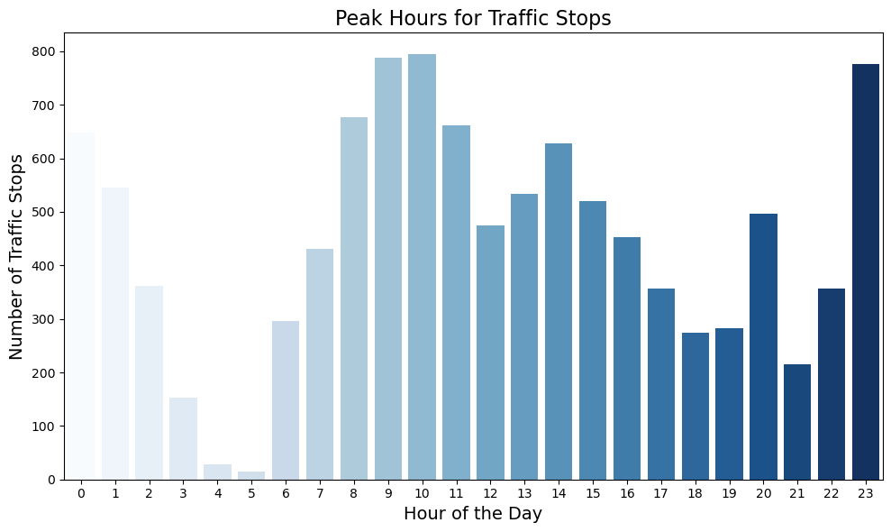

```python
#Determine peak hours for traffic stops.
# Group the data by 'stop_hour' and count the number of stops for each hour
hourly_stops = df_new['stop_hour'].value_counts().sort_index()
plt.figure(figsize=(10, 6))
sns.barplot(x=hourly_stops.index, y=hourly_stops.values, palette='Blues',hue=hourly_stops.index, legend=False)
plt.title('Peak Hours for Traffic Stops', fontsize=16)
plt.xlabel('Hour of the Day', fontsize=14)
plt.ylabel('Number of Traffic Stops', fontsize=14)
plt.xticks(range(24))
plt.tight_layout()
plt.show()
```

To determine the peak hours for traffic stops I used the code above. First I had to group the data by stop_hour and count the number of stops for each hour. df_new['stop_hour'].value_counts().sort_index() counts how many traffic stops occurred in each hour of the day (stop_hour), sorts the hours in chronological order using sort_index(). I chose to set the palette to Blues, I felt like this shows a clear distribution. plt.xticks(range(24)) ensures that all 24 hours (0 to 23) are shown on the x-axis. Then all I had to do was add my title, x and y label, and displayed the plot.

Identify peak times for traffic stops, such as during morning or evening rush hours- The peak times for traffic stops are in the morning (8-10 am), and at night (11pm), with a little peak around midday around 2pm. During the morning makes sense because people are making commutes to work and school with lots of traffic. Around 11pm makes sense as well because people usually speed more at night when people aren't on the road.

### Part 5: Analysis

```python
#Investigate whether certain driver demographics (e.g., gender, race) are disproportionately associated with specific violations.
contingency_table = pd.crosstab([df_new['driver_gender'], df_new['driver_race']], df_new['violation'], dropna=False)
contingency_table_normalized = contingency_table.div(contingency_table.sum(axis=1), axis=0)
print(contingency_table_normalized)
```

```
violation                  Equipment  Moving violation     Other  \
driver_gender driver_race
F             Asian         0.012821          0.051282  0.012821
              Black         0.086614          0.149606  0.019685
              Hispanic      0.000000          0.111111  0.037037
              Other         0.250000          0.250000  0.000000
              White         0.036335          0.096367  0.015008
M             Asian         0.025641          0.098291  0.012821
              Black         0.133981          0.191262  0.018447
              Hispanic      0.100000          0.221053  0.073684
              Other         0.037037          0.222222  0.037037
              White         0.061806          0.140354  0.018620

violation                  Registration/plates  Speeding
driver_gender driver_race
F             Asian                   0.025641  0.897436
              Black                   0.110236  0.633858
              Hispanic                0.000000  0.851852
              Other                   0.000000  0.500000
              White                   0.021722  0.830569
M             Asian                   0.004274  0.858974
              Black                   0.064078  0.592233
              Hispanic                0.052632  0.552632
              Other                   0.000000  0.703704
              White                   0.023314  0.755907
```

To investigate whether certain driver demographics (e.g., gender, race) are disproportionately associated with specific violations, I decided to create a contingency table with counts of violation for each combination of driver_gender and driver_race. div()): This normalizes the counts by dividing by the sum of counts per row (demographic group), so the result will be proportions rather than raw counts. Based on this contingency table, you can tell that the proportions are higher all under the speeding column. You could say that there are many disproportionately associations between the races and the violations because they are way too small.

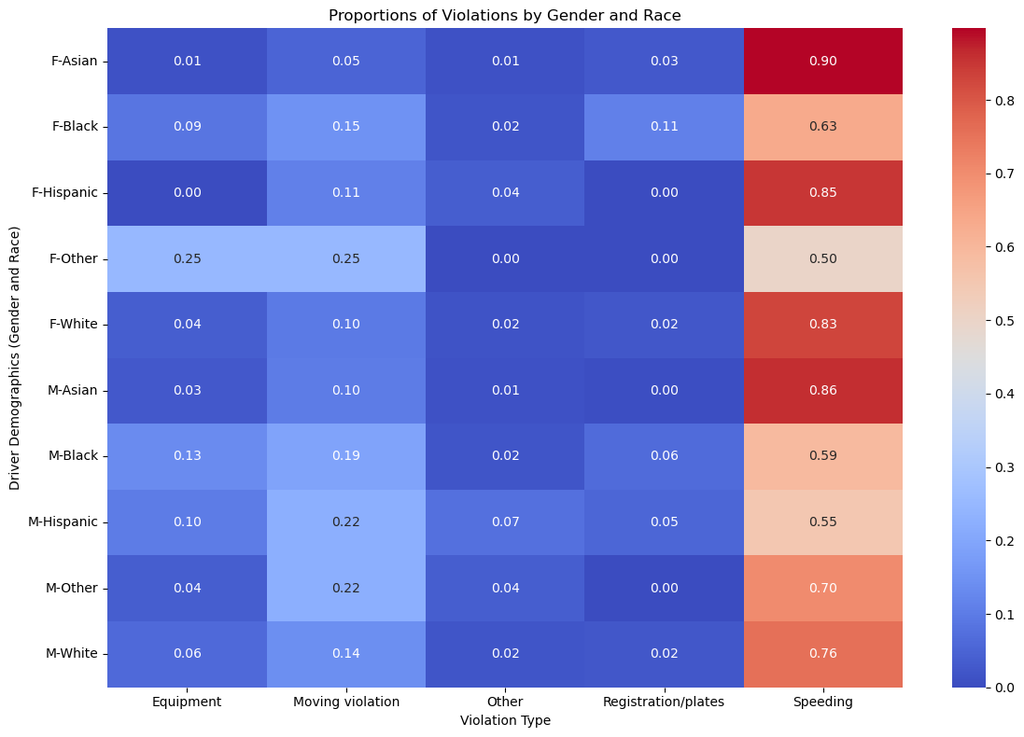

```python
# Plot a heatmap of the normalized values
plt.figure(figsize=(12, 8))
sns.heatmap(contingency_table_normalized, annot=True, cmap='coolwarm', fmt=".2f", cbar=True)

plt.title('Proportions of Violations by Gender and Race')
plt.xlabel('Violation Type')
plt.ylabel('Driver Demographics (Gender and Race)')
plt.tight_layout()
plt.show()
```

I also decided to plot a heatmap as well to show whether certain driver demographics (e.g., gender, race) are disproportionately associated with specific violations. The heatmap also shows what I was saying in the contingency table about speeding having the highest correlations with driver gender and driver race.

```python
# Create a contingency table to show counts of each combination of 'search_conducted' and 'is_arrested'
contingency_table = pd.crosstab(df_new['search_conducted'], df_new['is_arrested'], dropna=False)

# Display the contingency table
print(contingency_table)
```

```
is_arrested       False  True
search_conducted
False             10036    271
True                167    293
```

Earlier during the data visualization section we already examined these two categories in a stacked bar plot so I decided to use a contingency table this time. It shows us that most of the traffic stops didnt conduct a search and wasn't arrested. On the other hand, a search being conducted along with not being arrested is not common in the dataset.

### Part 6: Expected Output

### Question 1: Yearly Trend of Arrests

```python
arrests_by_year = df_new.groupby('stop_year')['is_arrested'].sum()

# Display the arrest counts by year
print(arrests_by_year)
```

```
stop_year
2005    183
2006    381
Name: is_arrested, dtype: object
```

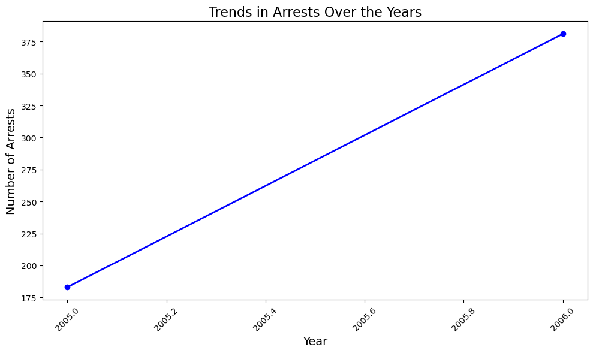

```python
plt.figure(figsize=(10, 6))
plt.plot(arrests_by_year.index, arrests_by_year.values, marker='o', color='b', linestyle='-', linewidth=2)

# Customize the plot
plt.title('Trends in Arrests Over the Years', fontsize=16)
plt.xlabel('Year', fontsize=14)
plt.ylabel('Number of Arrests', fontsize=14)
plt.xticks(rotation=45)
plt.tight_layout()
plt.show()
```

To create this visualization that is shown I had to first group stop_year and is_arrested together so that it could be the arrests by year. Then I wanted to display the arrests by year so you could see that after my data was cleaned only 2005 and 2006 had arrests. The next step was create the code for my plot by putting arrests by year. The next step was to customize my plot by adding the title, x and y labels, and then displaye it.

Based on this visualization and the data that was shown before it shows us that as the year up so does the arrests made. There were only two years that had arrests and in 2005 we went from 183 to 381 in 2006. If there were more years that had arrests we would be able to see probably more inclines and declines however the data is sligtly modified due to missing values and duplicates.

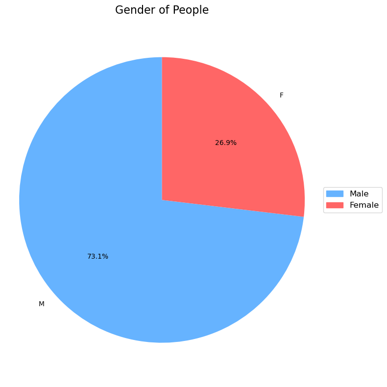

```python
# Count the occurrences of each gender
import matplotlib.patches as mpatches
gender_counts = df_new['driver_gender'].value_counts()
gender_counts = gender_counts[['Male', 'Female']] if 'Male' in gender_counts and 'Female' in gender_counts else gender_counts.sort_index(ascending=False)
# Create a pie chart with the gender counts
fig, ax = plt.subplots(figsize=(8, 8))
# Define colors for Male and Female
colors = ['#66b3ff', '#ff6666']  # Blue for Male, Red for Female
ax.pie(gender_counts, labels=gender_counts.index, autopct='%1.1f%%', startangle=90, colors=colors)
ax.set_title(f"Gender of People", fontsize=16)
# Create custom legend for Male and Female colors
male_patch = mpatches.Patch(color='#66b3ff', label='Male')
female_patch = mpatches.Patch(color='#ff6666', label='Female')
# Add the legend to the plot (hue for Male and Female on the side)
ax.legend(handles=[male_patch, female_patch], loc='center left', bbox_to_anchor=(1, 0.5), fontsize=12)
# Display the pie chart
ax.axis('equal')  # Equal aspect ratio ensures that pie is drawn as a circle.
plt.tight_layout()  # Adjust layout to avoid clipping the legend
plt.show()
```

### Part 7: Insights and Generalizations

```python
import plotly.express as px

# Count the occurrences of each gender
gender_counts = df_new['driver_gender'].value_counts()

# Plotly Pie Chart (interactive)
fig = px.pie(gender_counts, names=gender_counts.index, values=gender_counts,
             color=gender_counts.index, color_discrete_map={'Male': 'blue', 'Female': 'red'},
             title="Gender Distribution in Traffic Stops")

# Show the plot
fig.show()
```

[interactive chart not shown]

Using advanced visualizations, I chose to use Plotly to create an interactive pie chart, which allows users to hover over the chart for additional insights such as percentages and counts. As you can see its the same percentages as the other pie chart, but for this one you can hover over it and see the actual count. These advanced visualizations help you understand the dataset better.

```python
# Plotly Stacked Bar Chart
fig = px.histogram(df_new, x="driver_gender", color="is_arrested", barmode="stack",
                   title="Stacked Bar Plot: Search Conducted vs Arrested by Gender",
                   labels={"is_arrested": "Arrested", "driver_gender": "Gender"})

# Show the plot
fig.show()
```

[interactive chart not shown]